# House Prices: Advanced Regression Techniques Part1: Preprocessing

Vaibhav Gokhale

September 19, 2017

## Importing datas

**import the train and test data**

```r
train <- read.csv("train.csv",header = T,stringsAsFactors = F)
test <- read.csv("test.csv",header = T,stringsAsFactors = F)
# setdiff(names(train),names(test))
test$SalePrice <- rep(0,nrow(test))
train$trainORtest <- rep("train",nrow(train)) # Identifier
test$trainORtest <- rep("test",nrow(test))
```

**Combine the dataframes, assign appropriate datatypes**

```r
df <- rbind(train,test)
```

**Check structure of the data; Assign appropriate data types**

```r
# str(df)

# Remove ID (Not required)
df$Id <- NULL

# Categorical Variables
cat_var <- c("MSSubClass","OverallQual","OverallCond","MoSold","FullBath","HalfBath","BsmtFullBath","BsmtHalfBath","BedroomAbvGr","KitchenAbvGr","TotRmsAbvGrd","GarageCars","Fireplaces")
df[,cat_var] <- lapply(df[,cat_var],function(x)as.character(x))
```

## Missing values

**Total number of missing values**

```r
## Function for finding number of missing values in each column.
colmis <- function(df){
  miss <- sort(apply(df[,-ncol(df)],2,function(x)sum(is.na(x))),decreasing = T)
  miss[miss!=0]
}

colmis(df)
```

```
##       PoolQC  MiscFeature        Alley        Fence  FireplaceQu
##         2909         2814         2721         2348         1420
##  LotFrontage  GarageYrBlt GarageFinish   GarageQual   GarageCond
##          486          159          159          159          159
##   GarageType     BsmtCond BsmtExposure     BsmtQual BsmtFinType2
##          157           82           82           81           80
## BsmtFinType1   MasVnrType   MasVnrArea     MSZoning    Utilities
##           79           24           23            4            2
## BsmtFullBath BsmtHalfBath   Functional  Exterior1st  Exterior2nd
##            2            2            2            1            1
##   BsmtFinSF1   BsmtFinSF2    BsmtUnfSF  TotalBsmtSF   Electrical
##            1            1            1            1            1
##  KitchenQual   GarageCars   GarageArea     SaleType
##            1            1            1            1
```

## Strategy for imputing missing values

1. Perform exploraory data analysis(EDA). Perform the imputation based on the inferences of EDA.
2. For each variable, leave the remaining values as it is if there are no substantial evidences to impute these values.
3. After EDA, if unique rows with missing values are negligible delete those rows. Else, use KNN imputation or decision trees with subset of independent variables to impute them.

**NOTE : From the data description file following variables have NA as “No object”**  
These are treated as missing values by R.  
“Alley”,“BsmtQual”,“BsmtCond”,“BsmtExposure”,“BsmtFinType1”,“BsmtFinType2”,“FireplaceQu”,“GarageType”,“GarageFinish”,“GarageQual”,“GarageCond”,“PoolQC”,“Fence”,“MiscFeature”

#### Look at the missing values of each variable.

**PoolQC #NA=2909**

```r
sum(is.na(df$PoolQC[df$PoolArea==0])) #2906
```

```
## [1] 2906
```

```r
df$PoolQC[df$PoolArea==0 & is.na(df$PoolQC)] <- "N/A"
```

```
Still three values are missing. Plot the PoolArea vs PoolQC
```

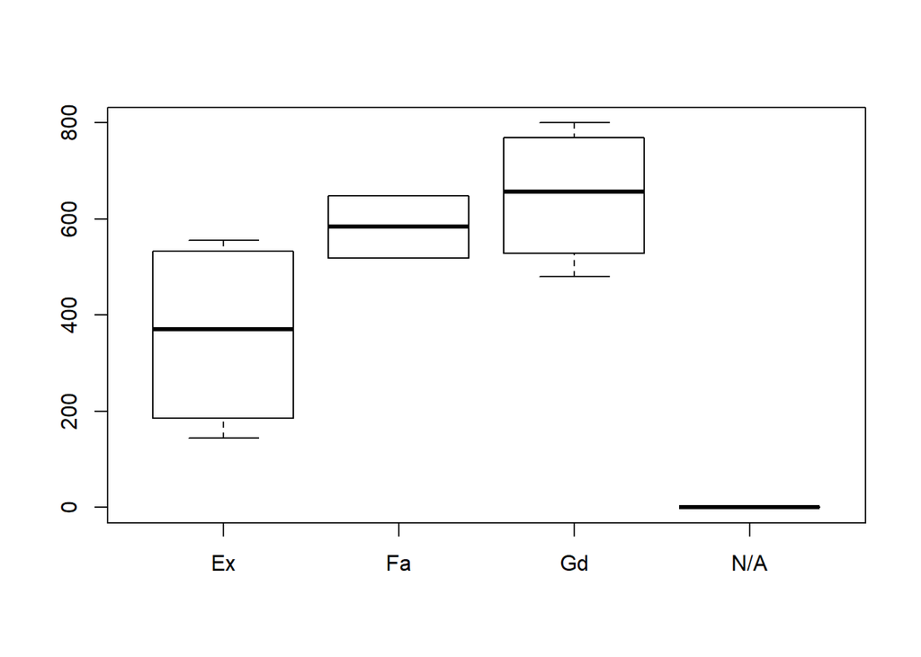

```r
boxplot(df$PoolArea~df$PoolQC)
```

See the pool areas where PoolQC values are still missing

```r
df$PoolArea[is.na(df$PoolQC)]
```

```
## [1] 368 444 561
```

```
Lets replace the PoolQC values according to their areas
```

```r
df$PoolQC[is.na(df$PoolQC) & df$PoolArea==368] <- "Ex"
df$PoolQC[is.na(df$PoolQC) & df$PoolArea==444] <- "Ex"
df$PoolQC[is.na(df$PoolQC) & df$PoolArea==561] <- "Fa"
```

**Misclaneous #NA = 2814**

```r
sum(is.na(df$MiscFeature[df$MiscVal==0])) #2813
```

```
## [1] 2813
```

```r
df$MiscFeature[is.na(df$MiscFeature) & df$MiscVal==0 ] <- "N/A"
```

**Alley #NA = 2721** * Intuitively, Alley is not correlated with any other variable

```r
df$Alley[is.na(df$Alley)] <- "N/A"
```

**Fence #NA = 2348** *Generally houses that have Pool have fence for privacy.*

```r
sum(is.na(df$Fence) & df$PoolArea==0)
```

```
## [1] 2344
```

```
Above logic stands; Same records have missing values in the column of Fence and PoolArea.
```

Replace thos values with “N/A”

```r
df$Fence[is.na(df$Fence) & df$PoolArea==0] <- "N/A"
table(df$PoolQC,df$Fence) ## When there is pool there is always fence.
```

```
##
##       GdPrv GdWo MnPrv MnWw  N/A
##   Ex      2    0     1    0    0
##   Fa      2    0     1    0    0
##   Gd      3    0     0    0    0
##   N/A   111  112   327   12 2344
```

```
It can be seen that, when there is pool. There is definitely some kind of fence
However, from the above frequency table it is hard to see any relation between fence quality and the pool quality
For the timebeing keep the missing values of fence as it is.
```

**FireplaceQu #NA=1420**

```r
sum(is.na(df$FireplaceQu) & df$Fireplaces==0)
```

```
## [1] 1420
```

```r
df$FireplaceQu[is.na(df$FireplaceQu) & df$Fireplaces==0] <- "N/A"
```

### LotFrontage #NA = 486

First intuition is that LotArea must be realted to the LotConfig.

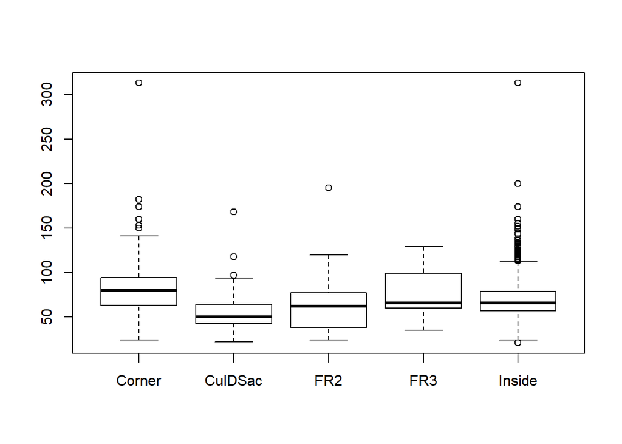

```
The above intuition holds. There is varition in the lot frontage based on the configuration.
```

```r
boxplot(df$LotFrontage~df$LotConfig)
```

With the Geometric consideration, the other variable that may cause variation in the lotfrontage is lot area.

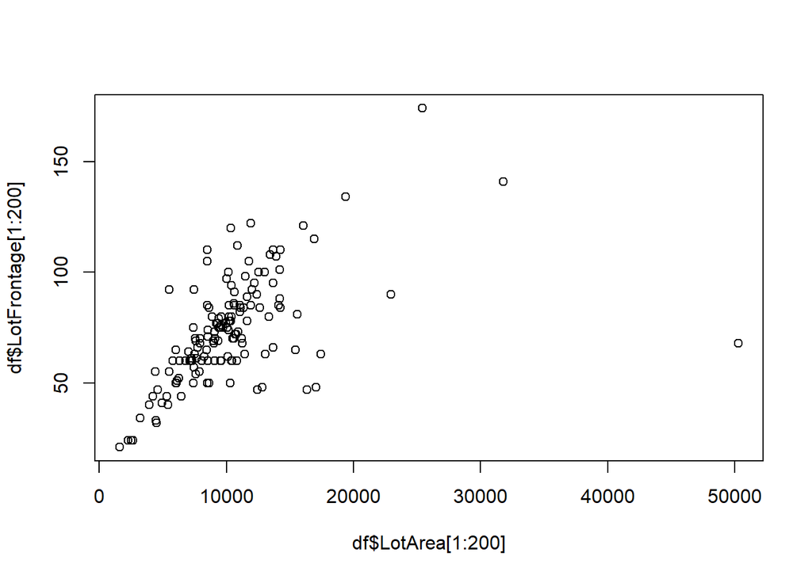

```r
plot(df$LotArea[1:200],df$LotFrontage[1:200])
```

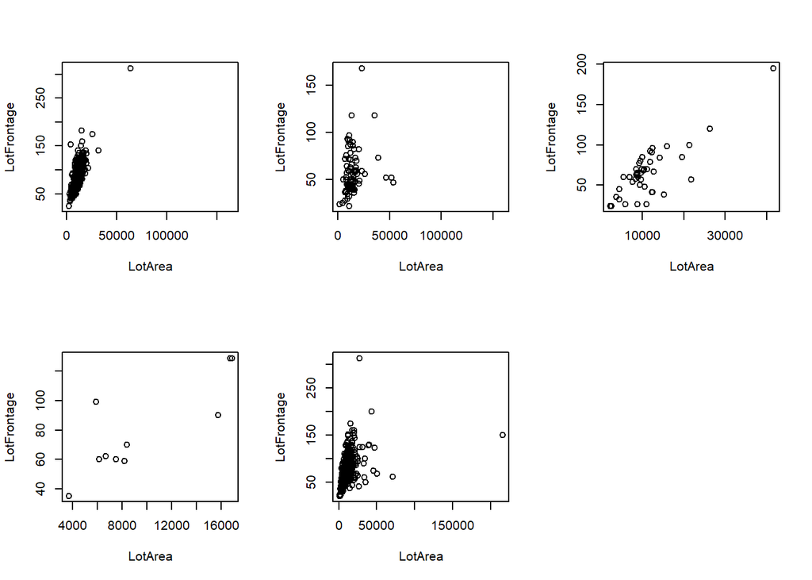

[output not shown]

```r
par(mfrow=c(2,3))
plot(df$LotArea[df$LotConfig=="Corner"],df$LotFrontage[df$LotConfig=="Corner"],xlab="LotArea",ylab="LotFrontage")
plot(df$LotArea[df$LotConfig=="CulDSac"],df$LotFrontage[df$LotConfig=="CulDSac"],xlab="LotArea",ylab="LotFrontage")
plot(df$LotArea[df$LotConfig=="FR2"],df$LotFrontage[df$LotConfig=="FR2"],xlab="LotArea",ylab="LotFrontage")
plot(df$LotArea[df$LotConfig=="FR3"],df$LotFrontage[df$LotConfig=="FR3"],xlab="LotArea",ylab="LotFrontage")
plot(df$LotArea[df$LotConfig=="Inside"],df$LotFrontage[df$LotConfig=="Inside"],xlab="LotArea",ylab="LotFrontage")
```

Let us check the correlation coefficients in each case

```r
Configs <- unique(df$LotConfig)
for (i in 1:length(Configs)){
  dftemp <- df[(df$LotConfig==Configs[i] & !(is.na(df$LotArea) | is.na(df$LotFrontage))),c("LotArea","LotFrontage")]
  corcoef <- cor(dftemp$LotArea,dftemp$LotFrontage)
  cat("Correlation Coefficient when LotConfig is",Configs[i],"=",corcoef,"\n")
}
```

```
## Correlation Coefficient when LotConfig is Inside = 0.4974775
## Correlation Coefficient when LotConfig is FR2 = 0.827626
## Correlation Coefficient when LotConfig is Corner = 0.7879552
## Correlation Coefficient when LotConfig is CulDSac = 0.1953268
## Correlation Coefficient when LotConfig is FR3 = 0.8358913
```

```r
rm(dftemp)
rm(Configs)
rm(corcoef)
```

[output not shown]

We can use linear regression models for imputation when the lot is at corner or has frontage on 2 or 3 sides Lets right a function to do this imputation

```r
imputeLinRegLotFr <- function(ConfigType){
  df_temp <- df[(df$LotConfig == ConfigType & !(is.na(df$LotArea) | is.na(df$LotFrontage))),c("LotArea","LotFrontage")]
  df_temp_impute <- df[(df$LotConfig == ConfigType & !is.na(df$LotArea) & is.na(df$LotFrontage)),c("LotArea","LotFrontage")]
  mod_lm <- lm(LotFrontage~LotArea,data = df_temp)
  predict(mod_lm,df_temp_impute)
}

df$LotFrontage[is.na(df$LotFrontage) & df$LotConfig == "FR2"] <- imputeLinRegLotFr("FR2")
df$LotFrontage[is.na(df$LotFrontage) & df$LotConfig == "FR3"] <- imputeLinRegLotFr("FR3")
df$LotFrontage[is.na(df$LotFrontage) & df$LotConfig == "Corner"] <- imputeLinRegLotFr("Corner")
rm(imputeLinRegLotFr)
```

```r
sum(is.na(df$LotFrontage))
```

```
## [1] 358
```

```
Still 358 values of LotFrontage are missing which is a large number.
```

Let us perform the Decision trees Imputation for the remaining values of the LotFrontage using CART algorithm for regression.

```r
# subset of possible independent variables as predictors.
predictors <- c("LotArea","LotConfig","LotShape","LandContour","LandSlope", "BldgType","HouseStyle","X1stFlrSF","LotFrontage")
df_pred <- df[,predictors]
dtrees <- rpart::rpart(LotFrontage~.,data = df_pred[1:nrow(train),])
df$LotFrontage <- predict(dtrees,newdata = df)
sum(is.na(df$LotFrontage))
```

```
## [1] 0
```

```r
rm(df_pred,dtrees,predictors)
```

**Garage related variables** GarageYrBlt #NA = 159 GarageFinish #NA = 159 GarageQual #NA = 159 GarageCond #NA = 159 GarageType #NA = 157

```r
sum(is.na(df$GarageYrBlt) & is.na(df$GarageFinish) & is.na(df$GarageQual) & is.na(df$GarageCond) & is.na(df$GarageType))
```

```
## [1] 157
```

```r
# Garage area for missing values of the garage related variables
table(df$GarageArea[is.na(df$GarageYrBlt) & is.na(df$GarageFinish) & is.na(df$GarageQual) & is.na(df$GarageCond) & is.na(df$GarageType)])
```

```
##
##   0
## 157
```

[output not shown]

Replace the missing values for these variables as “N/A”

```r
garage_missing_var <- c("GarageYrBlt","GarageFinish","GarageQual","GarageCond","GarageType")
df[,garage_missing_var][is.na(df[,garage_missing_var]) & df$GarageArea==0] <- "N/A"
rm(garage_missing_var)
```

**Basement related variables** BsmtCond #NA = 82 BsmtExposure #NA = 82 BsmtQual #NA = 81 BsmtFinType2 #NA = 80 BsmtFinType1 #NA = 79

```r
sum(is.na(df$BsmtCond) & is.na(df$BsmtExposure) & is.na(df$BsmtQual) & is.na(df$BsmtFinType2) & is.na(df$BsmtFinType1))
```

```
## [1] 79
```

```r
# Total basement area for the missing values of garage related variables
table(df$TotalBsmtSF[is.na(df$BsmtCond) & is.na(df$BsmtExposure) & is.na(df$BsmtQual) & is.na(df$BsmtFinType2) & is.na(df$BsmtFinType1) & df$TotalBsmtSF==0])
```

```
##
##  0
## 78
```

[output not shown]

Replace the missing values for these variables as “N/A”

```r
bsmt_var <- c("BsmtCond","BsmtQual","BsmtFinType2","BsmtFinType1")
df[,bsmt_var][is.na(df[,bsmt_var]) & df$TotalBsmtSF==0] <- "N/A"
df$BsmtExposure[is.na(df$BsmtExposure)] <- "No"
rm(bsmt_var)
```

**Veneer related variables** MasVnrType #NA = 24 MasVnrArea #NA = 23

```r
sum(is.na(df$MasVnrArea) & is.na(df$MasVnrType))
```

```
## [1] 23
```

```r
sum(df$MasVnrArea==0,na.rm = T)
```

```
## [1] 1738
```

```
23 of the missing values for masonry veneer type and masonry veneer area lie in the same row
Considerable number of masonry veneer area have value = 0
```

Let us replace missing values with “N/A” for type and 0 for area

```r
rows <- which(is.na(df$MasVnrType) & is.na(df$MasVnrArea), arr.ind=TRUE)
df$MasVnrArea[rows] <- 0
df$MasVnrType[rows] <- "N/A"
rm(rows)
```

**MSZoning #NA = 4** Intutively there should be some relation between zoning and neighbourhood Let us check it using frequency tables

```r
table(df$MSZoning,df$Neighborhood)
```

```
##
##           Blmngtn Blueste BrDale BrkSide ClearCr CollgCr Crawfor Edwards
##   C (all)       0       0      0       0       0       0       0       0
##   FV            0       0      0       0       0       0       0       0
##   RH            0       0      0       0       0       0       2       2
##   RL           25       0      0      43      44     253      91     180
##   RM            3      10     30      65       0      14      10      12
##
##           Gilbert IDOTRR MeadowV Mitchel NAmes NoRidge NPkVill NridgHt
##   C (all)       0     22       0       0     0       0       0       0
##   FV            0      0       0       0     0       0       0       0
##   RH            0      0       0       0     7       0       0       0
##   RL          165      0       0     104   436      71      23     165
##   RM            0     68      37       9     0       0       0       1
##
##           NWAmes OldTown Sawyer SawyerW Somerst StoneBr SWISU Timber
##   C (all)      0       2      0       0       0       0     1      0
##   FV           0       0      0       0     139       0     0      0
##   RH           0       0      0       6       0       0     9      0
##   RL         131      39    148     119      43      51    38     72
##   RM           0     198      3       0       0       0     0      0
##
##           Veenker
##   C (all)       0
##   FV            0
##   RH            0
##   RL           24
##   RM            0
```

```
From the above table, it is clear that most of the houses in a particular neighbourhood have a corresponding particular type of zoning classification
```

```r
df$Neighborhood[is.na(df$MSZoning)]
```

```
## [1] "IDOTRR"  "IDOTRR"  "IDOTRR"  "Mitchel"
```

```
Majority of the houses with neighbourhood "Mitchel" have RL that is residential low density zoning classification. It is fair to replace such missing values with "RL"
```

```r
df$MSZoning[is.na(df$MSZoning) & df$Neighborhood == "Mitchel"] <- "RL"
```

```
For Iowa DOT and Rail road neighbourhood there are 22 commercial and 68 Residential medium density zonings. It is difficult to decide which value should be used for imputation.
```

Let us also consider another relevant attribute which are condition1 and condition2

```r
table(df$Condition1[df$Neighborhood=="IDOTRR"],df$MSZoning[df$Neighborhood=="IDOTRR"])
```

```
##
##          C (all) RM
##   Artery       0  7
##   Feedr        6  0
##   Norm        16 57
##   RRAe         0  1
##   RRNe         0  2
##   RRNn         0  1
```

```r
table(df$Condition2[df$Neighborhood=="IDOTRR"],df$MSZoning[df$Neighborhood=="IDOTRR"])
```

```
##
##         C (all) RM
##   Feedr       1  0
##   Norm       21 68
```

```r
df$Condition1[is.na(df$MSZoning)]
```

```
## [1] "Norm" "Norm" "Norm"
```

```r
df$Condition2[is.na(df$MSZoning)]
```

```
## [1] "Norm" "Norm" "Norm"
```

```
All are norm. It is difficult to clearly decide the right imputation value.
```

*Missing values have been imputed for all the variables based on inferences from Exploratory Data Analysis (EDA) and CART decision trees for LotFrontage.*

As this is the competition. Any row cannot be deleted from the test data. Hence, separate the train and test data for final imputation process.  
Let us check unique number of rows with missing values in the train data

```r
sum(unique(is.na(df[df$trainORtest=="train",-ncol(df)])))
```

```
## [1] 3
```

```
There are only 3 unique rows which contain missing values in the train data.
```

Delete these rows from the train data.

```r
imputed_train <- na.omit(df[df$trainORtest=="train",])
sum(is.na(imputed_train))
```

```
## [1] 0
```

Let us work on the remaining missing values in the test data.  
Though there are negligible rows with missing values these rows cannot be removed as predictions are to be submitted for all observations.

```r
imputed_test <- df[df$trainORtest=="test",]
sum(is.na(imputed_test))
```

```
## [1] 43
```

```r
sum(unique(is.na(imputed_test)))
```

```
## [1] 38
```

```r
colmis(imputed_test)
```

```
##     BsmtCond     MSZoning     BsmtQual        Fence    Utilities
##            4            3            3            3            2
## BsmtFullBath BsmtHalfBath   Functional  GarageYrBlt GarageFinish
##            2            2            2            2            2
##   GarageQual   GarageCond  Exterior1st  Exterior2nd   MasVnrType
##            2            2            1            1            1
## BsmtFinType1   BsmtFinSF1 BsmtFinType2   BsmtFinSF2    BsmtUnfSF
##            1            1            1            1            1
##  TotalBsmtSF  KitchenQual   GarageCars   GarageArea  MiscFeature
##            1            1            1            1            1
##     SaleType
##            1
```

**Apply central imputation**

```r
imputed_test <- centralImputation(imputed_test)
```

Combine train and test dataframes again

```r
df <- rbind(imputed_train,imputed_test)
# rm(imputed_test,imputed_train)
```

## Feature Engineering

```r
df$AGEBuilt <- as.numeric(as.character(df$YrSold)) - df$YearBuilt
df$AgeMod <- as.numeric(as.character(df$YrSold)) - df$YearRemodAdd
df$TotalArea <- df$GrLivArea + df$X1stFlrSF + df$X2ndFlrSF
df$FinishedBsmtSF <- df$BsmtFinSF1 + df$BsmtFinSF2
df$TotalPorch <- df$OpenPorchSF + df$X3SsnPorch + df$ScreenPorch + df$EnclosedPorch

## Remove the variables which dont provide any information or which are not useful in prediction.
df$YearBuilt <- NULL
df$YearRemodAdd <- NULL
df$BsmtFinType2 <- NULL
df$BsmtFinSF2 <- NULL
df$LowQualFinSF <- NULL
df$PoolArea <- NULL
df$MiscVal <- NULL
df$X3SsnPorch <- NULL
```

## Feature trasnformations

**Target**

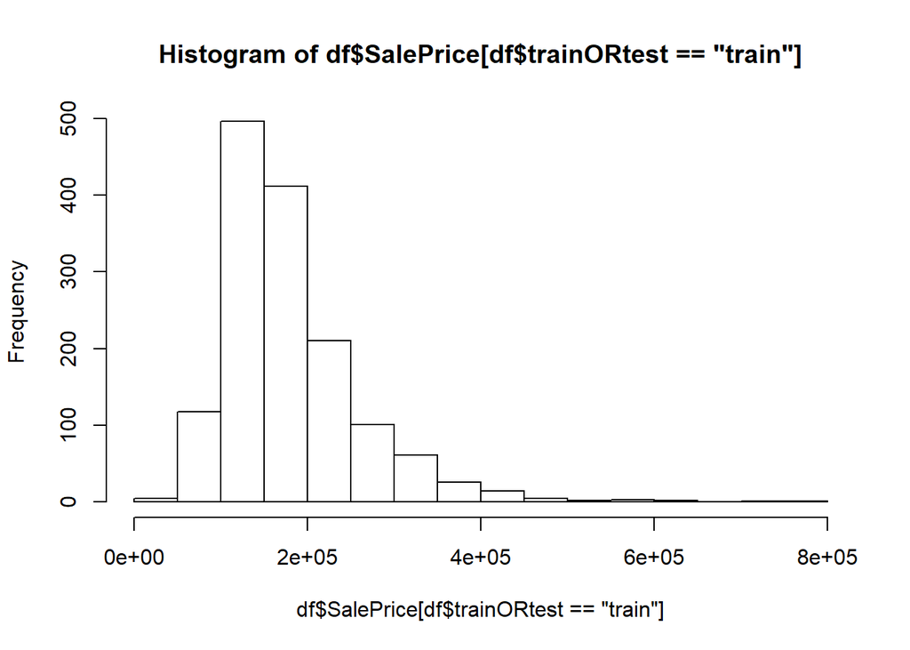

```r
hist(df$SalePrice[df$trainORtest=="train"])
```

```r
df$LogSalePrice <- ifelse(df$trainORtest=="train",log(df$SalePrice),0)
df$SalePrice <- NULL
```

**Check for the skewness of the variables**

```r
num_var <- names(df)[sapply(df,is.numeric)]
num_var <- num_var[num_var != "LogSalePrice"]
sort(sapply(num_var,function(x)skewness(df[x])),decreasing = T)
```

```
##               LotArea.LotArea   EnclosedPorch.EnclosedPorch
##                    13.0239937                     4.0015703
##       ScreenPorch.ScreenPorch       LotFrontage.LotFrontage
##                     3.9443047                     2.7432385
##         MasVnrArea.MasVnrArea       OpenPorchSF.OpenPorchSF
##                     2.6186134                     2.5384370
##         TotalPorch.TotalPorch         WoodDeckSF.WoodDeckSF
##                     2.2401009                     1.8429758
##           X1stFlrSF.X1stFlrSF           GrLivArea.GrLivArea
##                     1.2825153                     1.1279012
##           TotalArea.TotalArea         BsmtFinSF1.BsmtFinSF1
##                     1.1170950                     0.9926380
##           BsmtUnfSF.BsmtUnfSF           X2ndFlrSF.X2ndFlrSF
##                     0.9192537                     0.8630673
## FinishedBsmtSF.FinishedBsmtSF       TotalBsmtSF.TotalBsmtSF
##                     0.8050670                     0.6735719
##             AGEBuilt.AGEBuilt                 AgeMod.AgeMod
##                     0.5974651                     0.4487195
##         GarageArea.GarageArea                 YrSold.YrSold
##                     0.2184365                     0.1333922
```

**Perform the transformations on highly skewed variables**

```r
skewed_cols <- c()
for(i in num_var){
  if(abs(skewness(df[,i]))>=3){
    skewed_cols <- c(skewed_cols,i)
  }
}
for(i in skewed_cols){
  df[,i] <- df[,i]+1
  p1 <- powerTransform(df[,i])
  df[,i] <- bcPower(df[,i],lambda = p1$lambda,gamma = 1)
}

rm(skewed_cols)
```

**Convert the categorical variables into factors**

```r
cat_var <- names(which(sapply(df, is.character)))
df[,cat_var]<-lapply(df[,cat_var],function(x)as.factor(x))
df$GarageYrBlt <- NULL
df$YrSold <- as.factor(as.character(df$YrSold))
```

### Save the preprocessed train and test data.

```r
saveRDS(object = df,file = "df_preprocessed")
# saveRDS(object = df[df$trainORtest=="train",],file="train")
# saveRDS(object = df[df$trainORtest=="test",],file = "test")
```